# Matplotlib Practice Problems

Business Analytics with Python

Author

Dr. Smith

Published

March 4, 2025

## Matplotlib Practice Problems

Welcome to the Matplotlib practice problem set! This set is designed to reinforce your understanding of Matplotlib and its application in business analytics. Solve each problem by writing Python code that generates the requested plot.

### Problem Set

1. **Simple Line Plot:** Create a line plot showing the trend of daily website visitors over a week. Data: `[120, 150, 180, 200, 190, 220, 250]`. Label the axes appropriately.
2. **Comparative Line Plot:** Plot two lines representing the monthly sales of two products, A and B. Data: A: `[100, 120, 150, 130, 160]`, B: `[90, 110, 100, 140, 120]`. Add a legend.
3. **Bar Chart (Vertical):** Create a vertical bar chart showing the sales of four different regions: North, South, East, West. Data: `[300, 250, 280, 320]`. Label the bars.
4. **Bar Chart (Horizontal):** Create a horizontal bar chart comparing the performance of five departments: Marketing, Sales, Operations, HR, Finance. Data: `[85, 92, 78, 80, 88]`.
5. **Scatter Plot:** Plot a scatter plot showing the relationship between advertising spend and sales revenue. Data: Spend: `[100, 150, 200, 250, 300]`, Revenue: `[200, 350, 400, 500, 600]`.
6. **Histogram:** Create a histogram showing the distribution of customer ages. Data: `[25, 30, 35, 40, 45, 25, 30, 35, 40, 45, 50, 55, 60, 25, 30, 35, 40, 45, 50, 55]`.
7. **Pie Chart:** Create a pie chart showing the market share of four competitors: A, B, C, D. Data: `[40, 30, 20, 10]`.
8. **Subplots (2x1):** Create a figure with two subplots, one showing a line plot of monthly profits, and the other showing a bar chart of quarterly expenses.
9. **Subplots (1x2):** Create a figure with two subplots, one showing a scatter plot of customer age vs. purchase amount, and the other a histogram of purchase amounts.
10. **Customizing Line Plot:** Create a line plot with a dashed line, red color, and circle markers. Add a title and axis labels.
11. **Customizing Bar Chart:** Create a bar chart with blue bars, black edges, and data labels above each bar.
12. **Customizing Scatter Plot:** Create a scatter plot with different marker sizes based on a third variable. Add a colorbar.
13. **Pandas Line Plot:** Create a Pandas DataFrame with monthly sales data and plot it as a line chart.
14. **Pandas Bar Chart:** Create a Pandas DataFrame with product sales data and plot it as a bar chart.
15. **Pandas Histogram:** Create a Pandas DataFrame with customer age data and plot it as a histogram.
16. **Multiple Lines with Legend:** Plot three lines representing sales of three products (A, B, C) over time, and add a legend.
17. **Dual Axis Plot:** Create a plot with two y-axes, one showing sales revenue and the other showing the number of new customers.
18. **Stacked Bar Chart:** Create a stacked bar chart showing the sales contribution of three product lines (A, B, C) for each quarter.
19. **Annotated Plot:** Create a line plot and add annotations to highlight specific points or trends.
20. **Saving a Plot:** Create a scatter plot and save it as a PNG file with a resolution of 300 dpi.

## Appendix: Sample Solutions

```python
import matplotlib.pyplot as plt
import pandas as pd
import numpy as np
```

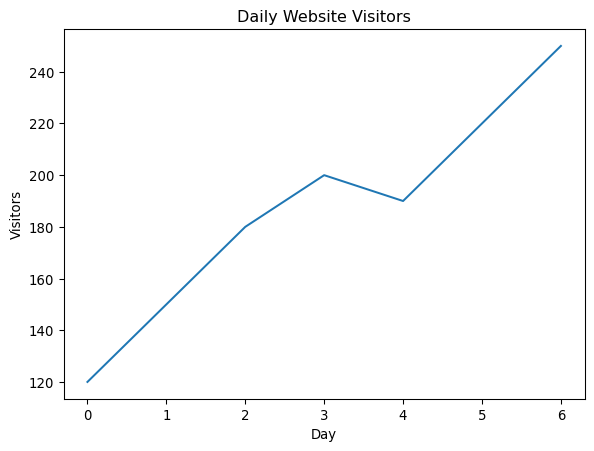

```python
# Problem 1
visitors = [120, 150, 180, 200, 190, 220, 250]
plt.plot(visitors)
plt.xlabel('Day')
plt.ylabel('Visitors')
plt.title('Daily Website Visitors')
plt.show()
```

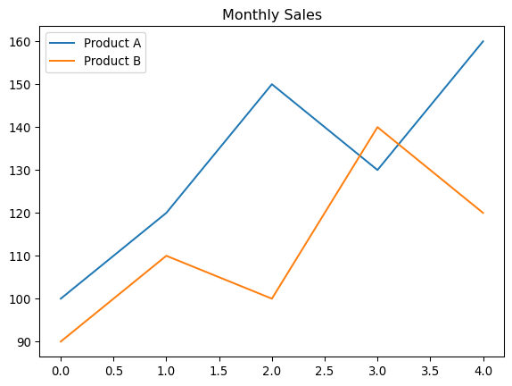

```python
# Problem 2
sales_a = [100, 120, 150, 130, 160]
sales_b = [90, 110, 100, 140, 120]
plt.plot(sales_a, label='Product A')
plt.plot(sales_b, label='Product B')
plt.legend()
plt.title('Monthly Sales')
plt.show()
```

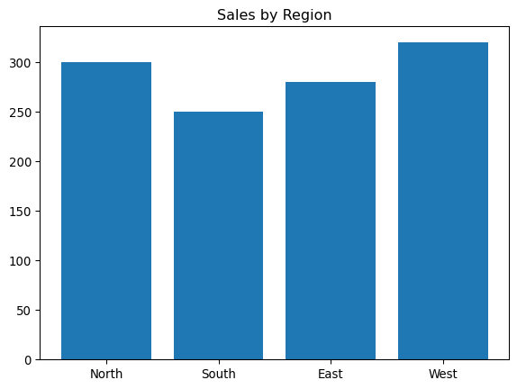

```python
# Problem 3
regions = ['North', 'South', 'East', 'West']
sales = [300, 250, 280, 320]
plt.bar(regions, sales)
plt.title('Sales by Region')
plt.show()
```

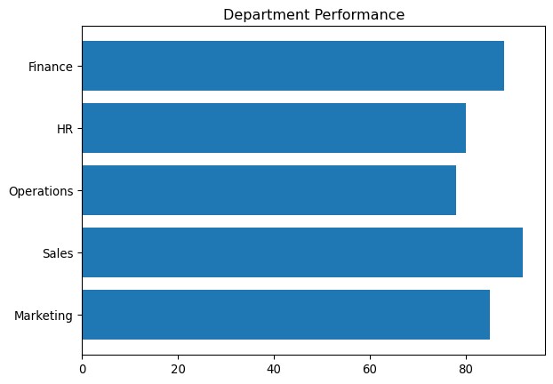

```python
# Problem 4
departments = ['Marketing', 'Sales', 'Operations', 'HR', 'Finance']
performance = [85, 92, 78, 80, 88]
plt.barh(departments, performance)
plt.title('Department Performance')
plt.show()
```

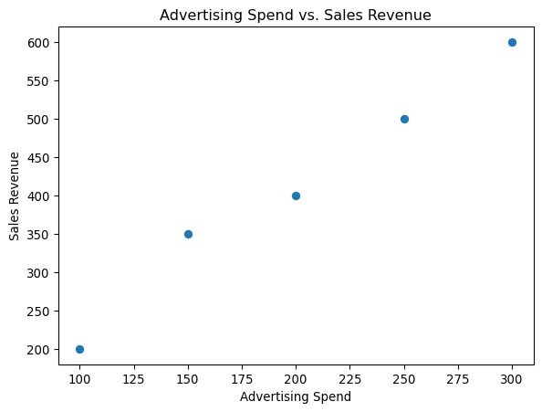

```python
# Problem 5
spend = [100, 150, 200, 250, 300]
revenue = [200, 350, 400, 500, 600]
plt.scatter(spend, revenue)
plt.xlabel('Advertising Spend')
plt.ylabel('Sales Revenue')
plt.title('Advertising Spend vs. Sales Revenue')
plt.show()
```

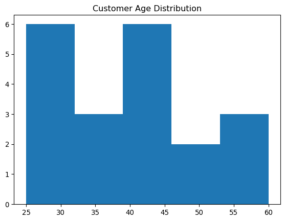

```python
# Problem 6
ages = [25, 30, 35, 40, 45, 25, 30, 35, 40, 45, 50, 55, 60, 25, 30, 35, 40, 45, 50, 55]
plt.hist(ages, bins=5)
plt.title('Customer Age Distribution')
plt.show()
```

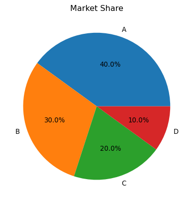

```python
# Problem 7
competitors = ['A', 'B', 'C', 'D']
market_share = [40, 30, 20, 10]
plt.pie(market_share, labels=competitors, autopct='%1.1f%%')
plt.title('Market Share')
plt.show()
```

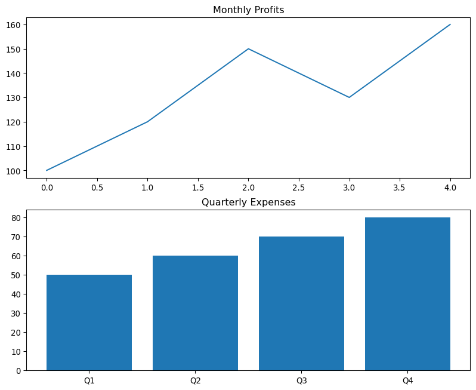

```python
# Problem 8
profits = [100, 120, 150, 130, 160]
expenses = [50, 60, 70, 80]
plt.figure(figsize=(10, 8))
plt.subplot(2, 1, 1)
plt.plot(profits)
plt.title('Monthly Profits')
plt.subplot(2, 1, 2)
plt.bar(['Q1', 'Q2', 'Q3', 'Q4'], expenses)
plt.title('Quarterly Expenses')
plt.show()
```

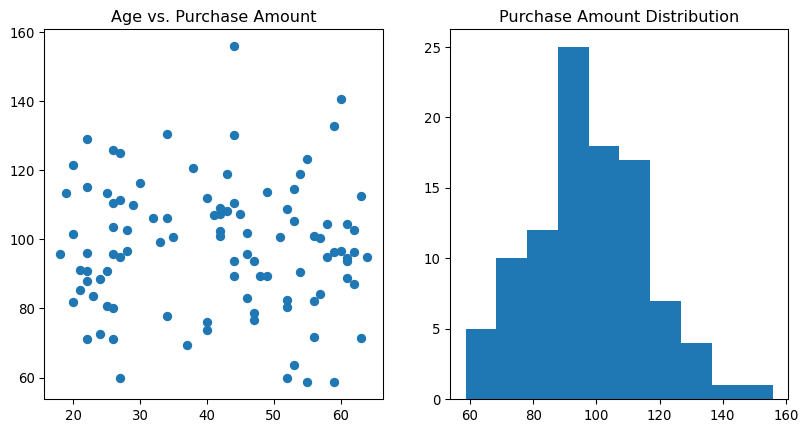

```python
# Problem 9
customer_age = np.random.randint(18, 65, 100)
purchase_amount = np.random.normal(100, 20, 100)
plt.figure(figsize=(10, 5))
plt.subplot(1, 2, 1)
plt.scatter(customer_age, purchase_amount)
plt.title('Age vs. Purchase Amount')
plt.subplot(1, 2, 2)
plt.hist(purchase_amount, bins=10)
plt.title('Purchase Amount Distribution')
plt.show()
```

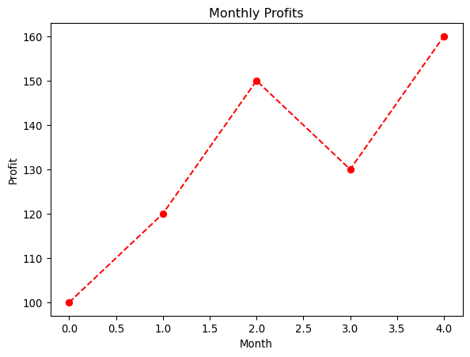

```python
# Problem 10
plt.plot(profits, linestyle='--', color='red', marker='o')
plt.title('Monthly Profits')
plt.xlabel('Month')
plt.ylabel('Profit')
plt.show()
```

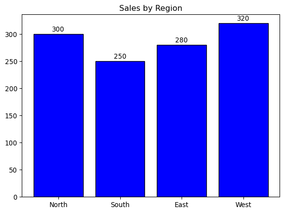

```python
# Problem 11
plt.bar(regions, sales, color='blue', edgecolor='black')
for i, v in enumerate(sales):
    plt.text(i, v + 5, str(v), ha='center')
plt.title('Sales by Region')
plt.show()
```

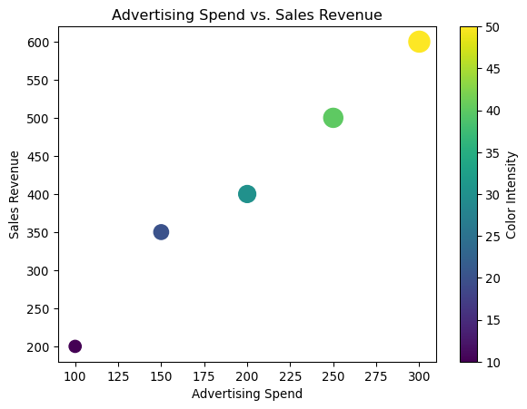

```python
# Problem 12
sizes = [100, 150, 200, 250, 300]
colors = [10, 20, 30, 40, 50]
plt.scatter(spend, revenue, s=sizes, c=colors, cmap='viridis')
plt.colorbar(label='Color Intensity')
plt.xlabel('Advertising Spend')
plt.ylabel('Sales Revenue')
plt.title('Advertising Spend vs. Sales Revenue')
plt.show()
```

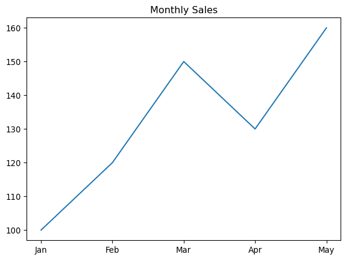

```python
# Problem 13
data = {'Month': ['Jan', 'Feb', 'Mar', 'Apr', 'May'], 'Sales': sales_a}
df = pd.DataFrame(data)
plt.plot(df['Month'], df['Sales'])
plt.title('Monthly Sales')
plt.show()
```

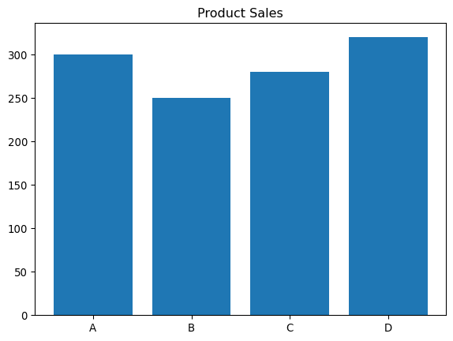

```python
# Problem 14
data = {'Product': ['A', 'B', 'C', 'D'], 'Sales': sales[:4]}
df = pd.DataFrame(data)
plt.bar(df['Product'], df['Sales'])
plt.title('Product Sales')
plt.show()
```

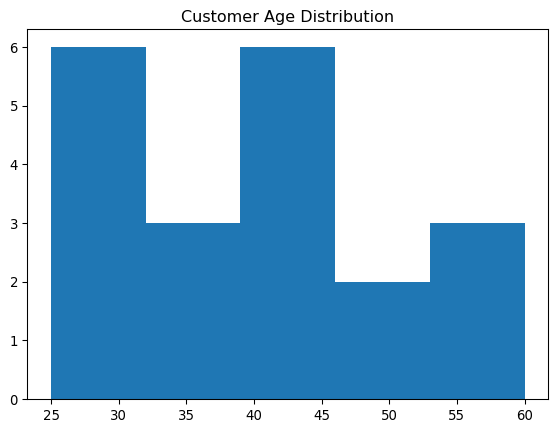

```python
# Problem 15
data = {'Age': ages}
df = pd.DataFrame(data)
plt.hist(df['Age'], bins=5)
plt.title('Customer Age Distribution')
plt.show()
```

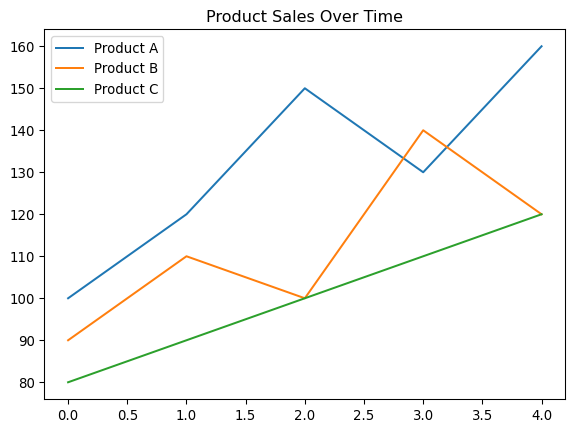

```python
# Problem 16
sales_c = [80, 90, 100, 110, 120]
plt.plot(sales_a, label='Product A')
plt.plot(sales_b, label='Product B')
plt.plot(sales_c, label='Product C')
plt.legend()
plt.title('Product Sales Over Time')
plt.show()
```

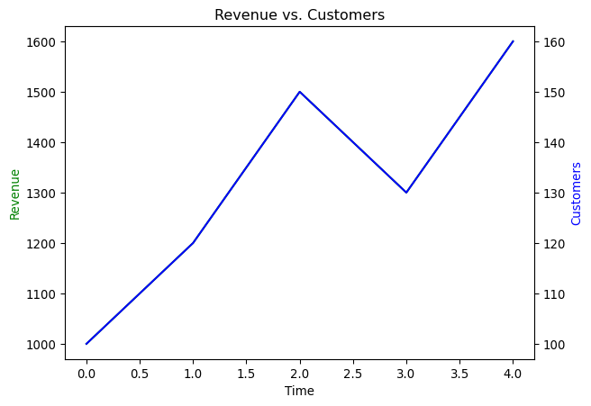

```python
# Problem 17
revenue = [1000, 1200, 1500, 1300, 1600]
customers = [100, 120, 150, 130, 160]
fig, ax1 = plt.subplots()
ax2 = ax1.twinx()
ax1.plot(revenue, 'g-')
ax2.plot(customers, 'b-')
ax1.set_xlabel('Time')
ax1.set_ylabel('Revenue', color='g')
ax2.set_ylabel('Customers', color='b')
plt.title('Revenue vs. Customers')
plt.show()
```

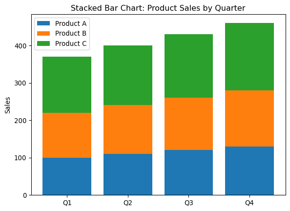

```python
# Problem 18
# Define data for each product across all 4 quarters
q1 = [100, 110, 120, 130]  # Product A data for all 4 quarters
q2 = [120, 130, 140, 150]  # Product B data for all 4 quarters
q3 = [150, 160, 170, 180]  # Product C data for all 4 quarters

quarters = ['Q1', 'Q2', 'Q3', 'Q4']

plt.bar(quarters, q1, label='Product A')
plt.bar(quarters, q2, bottom=q1, label='Product B')
plt.bar(quarters, q3, bottom=[a+b for a,b in zip(q1, q2)], label='Product C')

plt.legend()
plt.title('Stacked Bar Chart: Product Sales by Quarter')
plt.ylabel('Sales')
plt.show()
```

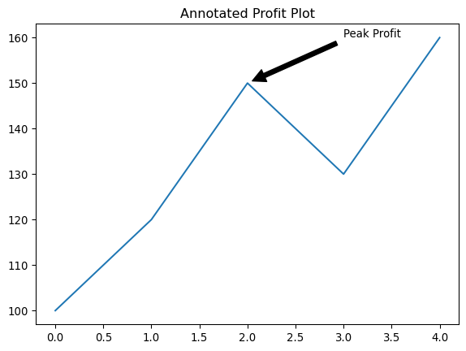

```python
# Problem 19
plt.plot(profits)
plt.annotate('Peak Profit', xy=(2, 150), xytext=(3, 160),
             arrowprops=dict(facecolor='black', shrink=0.05))
plt.title('Annotated Profit Plot')
plt.show()
```

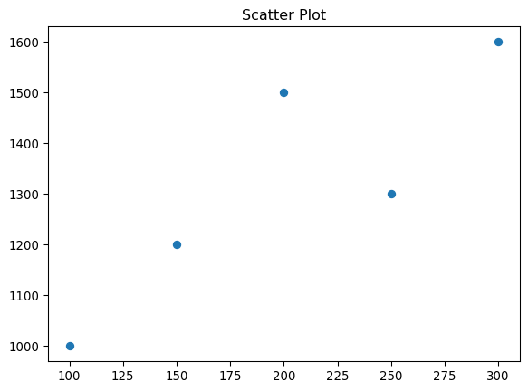

```python
# Problem 20
plt.scatter(spend, revenue)
plt.title('Scatter Plot')
plt.savefig('scatter_plot.png', dpi=300)
plt.show()
```